# Part I - prosperLoanData Exploration

## Introduction

- The prosperLoanData dataset contains 113,937 loans with 81 variables on each loan, including loan amount,borrower rate, current loan status, borrower income, Interest and Fees rates and many others.

## Preliminary Wrangling

```python
# import all packages and set plots to be embedded inline
import numpy as np
import pandas as pd
import matplotlib.pyplot as plt
import seaborn as sb

%matplotlib inline
```

> Load in your dataset and describe its properties through the questions below. Try and motivate your exploration goals through this section.

```python
#Load the dataset into a pandaset dataframe
df = pd.read_csv('prosperLoanData.csv')
```

```python
#Dimensions of the dataset
df.shape
```

```
(113937, 81)
```

```python
#Summary of the dataframe
df.info()
```

```
<class 'pandas.core.frame.DataFrame'>
RangeIndex: 113937 entries, 0 to 113936
Data columns (total 81 columns):
 #   Column                               Non-Null Count   Dtype
---  ------                               --------------   -----
 0   ListingKey                           113937 non-null  object
 1   ListingNumber                        113937 non-null  int64
 2   ListingCreationDate                  113937 non-null  object
 3   CreditGrade                          28953 non-null   object
 4   Term                                 113937 non-null  int64
 5   LoanStatus                           113937 non-null  object
 6   ClosedDate                           55089 non-null   object
 7   BorrowerAPR                          113912 non-null  float64
 8   BorrowerRate                         113937 non-null  float64
 9   LenderYield                          113937 non-null  float64
```

[output cut: 73 more lines]

```python
#Descriptive statistics of the data
df.describe()
```

|  | ListingNumber | Term | BorrowerAPR | BorrowerRate | LenderYield | EstimatedEffectiveYield | EstimatedLoss | EstimatedReturn | ProsperRating (numeric) | ProsperScore | ... | LP_ServiceFees | LP_CollectionFees | LP_GrossPrincipalLoss | LP_NetPrincipalLoss | LP_NonPrincipalRecoverypayments | PercentFunded | Recommendations | InvestmentFromFriendsCount | InvestmentFromFriendsAmount | Investors |
| --- | --- | --- | --- | --- | --- | --- | --- | --- | --- | --- | --- | --- | --- | --- | --- | --- | --- | --- | --- | --- | --- |
| count | 1.139370e+05 | 113937.000000 | 113912.000000 | 113937.000000 | 113937.000000 | 84853.000000 | 84853.000000 | 84853.000000 | 84853.000000 | 84853.000000 | ... | 113937.000000 | 113937.000000 | 113937.000000 | 113937.000000 | 113937.000000 | 113937.000000 | 113937.000000 | 113937.000000 | 113937.000000 | 113937.000000 |
| mean | 6.278857e+05 | 40.830248 | 0.218828 | 0.192764 | 0.182701 | 0.168661 | 0.080306 | 0.096068 | 4.072243 | 5.950067 | ... | -54.725641 | -14.242698 | 700.446342 | 681.420499 | 25.142686 | 0.998584 | 0.048027 | 0.023460 | 16.550751 | 80.475228 |
| std | 3.280762e+05 | 10.436212 | 0.080364 | 0.074818 | 0.074516 | 0.068467 | 0.046764 | 0.030403 | 1.673227 | 2.376501 | ... | 60.675425 | 109.232758 | 2388.513831 | 2357.167068 | 275.657937 | 0.017919 | 0.332353 | 0.232412 | 294.545422 | 103.239020 |
| min | 4.000000e+00 | 12.000000 | 0.006530 | 0.000000 | -0.010000 | -0.182700 | 0.004900 | -0.182700 | 1.000000 | 1.000000 | ... | -664.870000 | -9274.750000 | -94.200000 | -954.550000 | 0.000000 | 0.700000 | 0.000000 | 0.000000 | 0.000000 | 1.000000 |
| 25% | 4.009190e+05 | 36.000000 | 0.156290 | 0.134000 | 0.124200 | 0.115670 | 0.042400 | 0.074080 | 3.000000 | 4.000000 | ... | -73.180000 | 0.000000 | 0.000000 | 0.000000 | 0.000000 | 1.000000 | 0.000000 | 0.000000 | 0.000000 | 2.000000 |
| 50% | 6.005540e+05 | 36.000000 | 0.209760 | 0.184000 | 0.173000 | 0.161500 | 0.072400 | 0.091700 | 4.000000 | 6.000000 | ... | -34.440000 | 0.000000 | 0.000000 | 0.000000 | 0.000000 | 1.000000 | 0.000000 | 0.000000 | 0.000000 | 44.000000 |
| 75% | 8.926340e+05 | 36.000000 | 0.283810 | 0.250000 | 0.240000 | 0.224300 | 0.112000 | 0.116600 | 5.000000 | 8.000000 | ... | -13.920000 | 0.000000 | 0.000000 | 0.000000 | 0.000000 | 1.000000 | 0.000000 | 0.000000 | 0.000000 | 115.000000 |
| max | 1.255725e+06 | 60.000000 | 0.512290 | 0.497500 | 0.492500 | 0.319900 | 0.366000 | 0.283700 | 7.000000 | 11.000000 | ... | 32.060000 | 0.000000 | 25000.000000 | 25000.000000 | 21117.900000 | 1.012500 | 39.000000 | 33.000000 | 25000.000000 | 1189.000000 |

8 rows × 61 columns

```python
df.head()
```

|  | ListingKey | ListingNumber | ListingCreationDate | CreditGrade | Term | LoanStatus | ClosedDate | BorrowerAPR | BorrowerRate | LenderYield | ... | LP_ServiceFees | LP_CollectionFees | LP_GrossPrincipalLoss | LP_NetPrincipalLoss | LP_NonPrincipalRecoverypayments | PercentFunded | Recommendations | InvestmentFromFriendsCount | InvestmentFromFriendsAmount | Investors |
| --- | --- | --- | --- | --- | --- | --- | --- | --- | --- | --- | --- | --- | --- | --- | --- | --- | --- | --- | --- | --- | --- |
| 0 | 1021339766868145413AB3B | 193129 | 2007-08-26 19:09:29.263000000 | C | 36 | Completed | 2009-08-14 00:00:00 | 0.16516 | 0.1580 | 0.1380 | ... | -133.18 | 0.0 | 0.0 | 0.0 | 0.0 | 1.0 | 0 | 0 | 0.0 | 258 |
| 1 | 10273602499503308B223C1 | 1209647 | 2014-02-27 08:28:07.900000000 | NaN | 36 | Current | NaN | 0.12016 | 0.0920 | 0.0820 | ... | 0.00 | 0.0 | 0.0 | 0.0 | 0.0 | 1.0 | 0 | 0 | 0.0 | 1 |
| 2 | 0EE9337825851032864889A | 81716 | 2007-01-05 15:00:47.090000000 | HR | 36 | Completed | 2009-12-17 00:00:00 | 0.28269 | 0.2750 | 0.2400 | ... | -24.20 | 0.0 | 0.0 | 0.0 | 0.0 | 1.0 | 0 | 0 | 0.0 | 41 |
| 3 | 0EF5356002482715299901A | 658116 | 2012-10-22 11:02:35.010000000 | NaN | 36 | Current | NaN | 0.12528 | 0.0974 | 0.0874 | ... | -108.01 | 0.0 | 0.0 | 0.0 | 0.0 | 1.0 | 0 | 0 | 0.0 | 158 |
| 4 | 0F023589499656230C5E3E2 | 909464 | 2013-09-14 18:38:39.097000000 | NaN | 36 | Current | NaN | 0.24614 | 0.2085 | 0.1985 | ... | -60.27 | 0.0 | 0.0 | 0.0 | 0.0 | 1.0 | 0 | 0 | 0.0 | 20 |

5 rows × 81 columns

### What is the structure of your dataset?

- There are 113,937 loans in the dataset with different variables including loan amount,borrower rate, current loan status, borrower income, Interest and Fees rates and many others. Since it's a dataset abount loans, most variables are numeric with a few variables beingcategorical data types such as Occupation, Loan Status, Employment Status.

### What is/are the main feature(s) of interest in your dataset?

- The dataset contains 81 variables which all won't be my areas of focus. I'm most interested in figuring out the relationships between/among various variables. Examples:

  > Is the employment status of an individual affect their loan status or their CreditScore Rating?

  > Are most of the loans completely paid off?

  > Does an individual's monthly income affect the amount of loan approved?

  > Are individuals who are employed/self employed have a higher monthly loan payment compared to the unemployed/retired?

  > Do borrowers who are home owners or employed have a better credit score than the ones who are not?

### What features in the dataset do you think will help support your investigation into your feature(s) of interest?

- There are a couple of features that I think will help supporting my investigation. These includes:

  > I expect majority of the borrowers who have been employed/self-employed for a longer duration have a higher CreditScore rating.

  > I expect that borrowers who have jobs to have a higher monthly payment compared to the ones that do not.

  > I expect home owners to have a better credit score that the ones who are not.

## Univariate Exploration

- I'll start by filtering the columns I'll be using for the data exploration using Pandas' filter function, since I won't be needing all the 81 columns.
- The data will thereafter be cleaned for easier data exploration in this section and the others

```python
df1 = df.filter(items=['ListingNumber', 'Term', 'LoanStatus', 'BorrowerRate', 'ProsperScore', 'ListingCategory', 'EmploymentStatus', 'EmploymentStatusDuration', 'IsBorrowerHomeowner', 'CreditScoreRangeLower', 'StatedMonthlyIncome', 'TotalProsperLoans', 'LoanMonthsSinceOrigination', 'LoanOriginalAmount', 'MonthlyLoanPayment', 'TotalProsperPaymentsBilled', 'LP_CustomerPayments', 'LP_GrossPrincipalLoss'])
```

```python
df1.head(5)
```

|  | ListingNumber | Term | LoanStatus | BorrowerRate | ProsperScore | EmploymentStatus | EmploymentStatusDuration | IsBorrowerHomeowner | CreditScoreRangeLower | StatedMonthlyIncome | TotalProsperLoans | LoanMonthsSinceOrigination | LoanOriginalAmount | MonthlyLoanPayment | TotalProsperPaymentsBilled | LP_CustomerPayments | LP_GrossPrincipalLoss |
| --- | --- | --- | --- | --- | --- | --- | --- | --- | --- | --- | --- | --- | --- | --- | --- | --- | --- |
| 0 | 193129 | 36 | Completed | 0.1580 | NaN | Self-employed | 2.0 | True | 640.0 | 3083.333333 | NaN | 78 | 9425 | 330.43 | NaN | 11396.14 | 0.0 |
| 1 | 1209647 | 36 | Current | 0.0920 | 7.0 | Employed | 44.0 | False | 680.0 | 6125.000000 | NaN | 0 | 10000 | 318.93 | NaN | 0.00 | 0.0 |
| 2 | 81716 | 36 | Completed | 0.2750 | NaN | Not available | NaN | False | 480.0 | 2083.333333 | NaN | 86 | 3001 | 123.32 | NaN | 4186.63 | 0.0 |
| 3 | 658116 | 36 | Current | 0.0974 | 9.0 | Employed | 113.0 | True | 800.0 | 2875.000000 | NaN | 16 | 10000 | 321.45 | NaN | 5143.20 | 0.0 |
| 4 | 909464 | 36 | Current | 0.2085 | 4.0 | Employed | 44.0 | True | 680.0 | 9583.333333 | 1.0 | 6 | 15000 | 563.97 | 11.0 | 2819.85 | 0.0 |

```python
#Dimensions of the filtered dataset
df1.shape
```

```
(113937, 17)
```

```python
#Check for the sum of all the null values in the dataset
df1.isna().sum()
```

```
ListingNumber                     0
Term                              0
LoanStatus                        0
BorrowerRate                      0
ProsperScore                  29084
EmploymentStatus               2255
EmploymentStatusDuration       7625
IsBorrowerHomeowner               0
CreditScoreRangeLower           591
StatedMonthlyIncome               0
TotalProsperLoans             91852
LoanMonthsSinceOrigination        0
LoanOriginalAmount                0
MonthlyLoanPayment                0
TotalProsperPaymentsBilled    91852
LP_CustomerPayments               0
LP_GrossPrincipalLoss             0
dtype: int64
```

```python
#Rename some columns that have long column names to make the dataset more tidy
df1.rename(columns={'BorrowerRate':'InterestRate', 'EmploymentStatusDuration':'EmploymentDuration', 'IsBorrowerHomeOwner':'IsHomeOwner','CreditScoreRangeLower':'CreditScore', 'StatedMonthlyIncome':'MonthlyIncome', 'TotalProsperLoans':'ProsperLoans', 'LoanMonthsSinceOrigination':'LoanStretch', 'LoanOriginalAmount':'OriginalLoan', 'MonthlyLoanPayment':'MonthlyPayment', 'TotalProsperPaymentsBilled':'TotalProsperPaid'}, inplace=True)
```

```python
df1.sample(5)
```

|  | ListingNumber | Term | LoanStatus | InterestRate | ProsperScore | EmploymentStatus | EmploymentDuration | IsBorrowerHomeowner | CreditScore | MonthlyIncome | ProsperLoans | LoanStretch | OriginalLoan | MonthlyPayment | TotalProsperPaid | LP_CustomerPayments | LP_GrossPrincipalLoss |
| --- | --- | --- | --- | --- | --- | --- | --- | --- | --- | --- | --- | --- | --- | --- | --- | --- | --- |
| 91676 | 962341 | 60 | Current | 0.1660 | 7.0 | Employed | 27.0 | False | 700.0 | 10416.666667 | NaN | 5 | 10000 | 246.38 | NaN | 970.5200 | 0.0 |
| 34863 | 1102941 | 60 | Current | 0.2694 | 3.0 | Employed | 6.0 | False | 680.0 | 4166.666667 | NaN | 3 | 10000 | 304.99 | NaN | 602.5992 | 0.0 |
| 83245 | 502964 | 36 | Completed | 0.3199 | 4.0 | Employed | 31.0 | True | 800.0 | 2250.000000 | NaN | 35 | 7500 | 326.62 | NaN | 11539.0500 | 0.0 |
| 75067 | 657982 | 36 | Current | 0.1509 | 8.0 | Employed | 47.0 | False | 680.0 | 9666.666667 | NaN | 16 | 20900 | 725.43 | NaN | 11906.8800 | 0.0 |
| 42517 | 255274 | 36 | Completed | 0.2500 | NaN | Full-time | 83.0 | False | 520.0 | 3500.000000 | NaN | 74 | 3000 | 119.28 | NaN | 4195.1500 | 0.0 |

```python
#Check the various employment statuses in the dataset
df1['EmploymentStatus'].value_counts()
```

```
Employed         67322
Full-time        26355
Self-employed     6134
Not available     5347
Other             3806
Part-time         1088
Not employed       835
Retired            795
Name: EmploymentStatus, dtype: int64
```

```python
#Use the replace function to replace 'Not employed' with 'Employed'
df1.replace(to_replace='Not employed', value='Unemployed', inplace=True)
```

```python
df1['EmploymentStatus'].value_counts()
```

```
Employed         67322
Full-time        26355
Self-employed     6134
Not available     5347
Other             3806
Part-time         1088
Unemployed         835
Retired            795
Name: EmploymentStatus, dtype: int64
```

```python
#Instead of having 'Not available', use NaN
df1.replace('Not available', np.NaN, inplace=True)
```

```python
df1['EmploymentStatus'].value_counts()
```

```
Employed         67322
Full-time        26355
Self-employed     6134
Other             3806
Part-time         1088
Unemployed         835
Retired            795
Name: EmploymentStatus, dtype: int64
```

```python
df1.info()
```

```
<class 'pandas.core.frame.DataFrame'>
RangeIndex: 113937 entries, 0 to 113936
Data columns (total 17 columns):
 #   Column                 Non-Null Count   Dtype
---  ------                 --------------   -----
 0   ListingNumber          113937 non-null  int64
 1   Term                   113937 non-null  int64
 2   LoanStatus             113937 non-null  object
 3   InterestRate           113937 non-null  float64
 4   ProsperScore           84853 non-null   float64
 5   EmploymentStatus       106335 non-null  object
 6   EmploymentDuration     106312 non-null  float64
 7   IsBorrowerHomeowner    113937 non-null  bool
 8   CreditScore            113346 non-null  float64
 9   MonthlyIncome          113937 non-null  float64
 10  ProsperLoans           22085 non-null   float64
 11  LoanStretch            113937 non-null  int64
 12  OriginalLoan           113937 non-null  int64
 13  MonthlyPayment         113937 non-null  float64
 14  TotalProsperPaid       22085 non-null   float64
 15  LP_CustomerPayments    113937 non-null  float64
 16  LP_GrossPrincipalLoss  113937 non-null  float64
dtypes: bool(1), float64(10), int64(4), object(2)
memory usage: 14.0+ MB
```

```python
#Get a copy of the dataset before cleaning the data for explaration
df_clean = df1.copy()
```

```python
# Drop null values
df_clean = df_clean.dropna()
```

```python
df_clean.head()
```

|  | ListingNumber | Term | LoanStatus | InterestRate | ProsperScore | EmploymentStatus | EmploymentDuration | IsBorrowerHomeowner | CreditScore | MonthlyIncome | ProsperLoans | LoanStretch | OriginalLoan | MonthlyPayment | TotalProsperPaid | LP_CustomerPayments | LP_GrossPrincipalLoss |
| --- | --- | --- | --- | --- | --- | --- | --- | --- | --- | --- | --- | --- | --- | --- | --- | --- | --- |
| 4 | 909464 | 36 | Current | 0.2085 | 4.0 | Employed | 44.0 | True | 680.0 | 9583.333333 | 1.0 | 6 | 15000 | 563.97 | 11.0 | 2819.8500 | 0.0 |
| 16 | 841846 | 60 | Current | 0.2809 | 4.0 | Full-time | 133.0 | True | 640.0 | 8291.666667 | 3.0 | 8 | 4000 | 124.76 | 67.0 | 873.3200 | 0.0 |
| 19 | 875565 | 60 | Current | 0.2225 | 8.0 | Employed | 18.0 | False | 680.0 | 3075.000000 | 1.0 | 5 | 6500 | 180.45 | 12.0 | 717.8377 | 0.0 |
| 33 | 478891 | 36 | Completed | 0.0785 | 10.0 | Employed | 7.0 | False | 760.0 | 13083.333333 | 1.0 | 41 | 16000 | 500.28 | 8.0 | 17544.9500 | 0.0 |
| 47 | 765126 | 36 | Current | 0.1299 | 8.0 | Employed | 90.0 | True | 680.0 | 5416.666667 | 3.0 | 10 | 15000 | 505.34 | 20.0 | 4737.3800 | 0.0 |

```python
#There's a significant change in the number of loans after dropping rows containing null values
df_clean.shape
```

```
(19793, 17)
```

```python
#Change the datatype of some columns from float to int using Pandas astype function
df_clean = df_clean.astype({'EmploymentDuration':'int64', 'ProsperLoans':'int64', 'TotalProsperPaid':'int64'})
```

```python
#Confirm the datatypes have been changed
df_clean.info()
```

```
<class 'pandas.core.frame.DataFrame'>
Int64Index: 19793 entries, 4 to 113935
Data columns (total 17 columns):
 #   Column                 Non-Null Count  Dtype
---  ------                 --------------  -----
 0   ListingNumber          19793 non-null  int64
 1   Term                   19793 non-null  int64
 2   LoanStatus             19793 non-null  object
 3   InterestRate           19793 non-null  float64
 4   ProsperScore           19793 non-null  float64
 5   EmploymentStatus       19793 non-null  object
 6   EmploymentDuration     19793 non-null  int64
 7   IsBorrowerHomeowner    19793 non-null  bool
 8   CreditScore            19793 non-null  float64
 9   MonthlyIncome          19793 non-null  float64
 10  ProsperLoans           19793 non-null  int64
 11  LoanStretch            19793 non-null  int64
 12  OriginalLoan           19793 non-null  int64
 13  MonthlyPayment         19793 non-null  float64
 14  TotalProsperPaid       19793 non-null  int64
 15  LP_CustomerPayments    19793 non-null  float64
 16  LP_GrossPrincipalLoss  19793 non-null  float64
dtypes: bool(1), float64(7), int64(7), object(2)
memory usage: 2.6+ MB
```

```python
df_clean.describe()
```

|  | ListingNumber | Term | InterestRate | ProsperScore | EmploymentDuration | CreditScore | MonthlyIncome | ProsperLoans | LoanStretch | OriginalLoan | MonthlyPayment | TotalProsperPaid | LP_CustomerPayments | LP_GrossPrincipalLoss |
| --- | --- | --- | --- | --- | --- | --- | --- | --- | --- | --- | --- | --- | --- | --- |
| count | 1.979300e+04 | 19793.000000 | 19793.000000 | 19793.000000 | 19793.000000 | 19793.000000 | 19793.000000 | 19793.000000 | 19793.000000 | 19793.000000 | 19793.000000 | 19793.000000 | 19793.000000 | 19793.000000 |
| mean | 6.823185e+05 | 42.248270 | 0.191262 | 6.174304 | 103.375537 | 686.853938 | 5947.454428 | 1.460718 | 20.906785 | 7875.389633 | 253.911442 | 24.303693 | 4465.573337 | 466.639522 |
| std | 2.034226e+05 | 11.754289 | 0.077861 | 2.713132 | 91.549473 | 51.998556 | 4292.942493 | 0.790496 | 14.278514 | 5404.444648 | 162.875442 | 19.773178 | 4333.588244 | 1916.242164 |
| min | 4.162750e+05 | 12.000000 | 0.040000 | 1.000000 | 0.000000 | 600.000000 | 0.000000 | 0.000000 | 0.000000 | 1000.000000 | 0.000000 | 0.000000 | 0.000000 | 0.000000 |
| 25% | 5.241280e+05 | 36.000000 | 0.126900 | 4.000000 | 36.000000 | 640.000000 | 3483.333333 | 1.000000 | 9.000000 | 4000.000000 | 130.950000 | 10.000000 | 1367.190000 | 0.000000 |
| 50% | 6.201350e+05 | 36.000000 | 0.184500 | 6.000000 | 76.000000 | 680.000000 | 5000.000000 | 1.000000 | 19.000000 | 6500.000000 | 214.980000 | 18.000000 | 3044.235500 | 0.000000 |
| 75% | 8.053400e+05 | 60.000000 | 0.254900 | 8.000000 | 144.000000 | 720.000000 | 7250.000000 | 2.000000 | 30.000000 | 11000.000000 | 346.500000 | 35.000000 | 6128.800000 | 0.000000 |
| max | 1.255725e+06 | 60.000000 | 0.360000 | 11.000000 | 690.000000 | 880.000000 | 150000.000000 | 8.000000 | 56.000000 | 35000.000000 | 2134.060000 | 141.000000 | 35579.420000 | 24423.560000 |

## Univariate Exploration

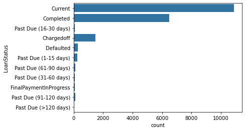

```python
#Start plotting the categorical variables on a standard plot
base_color = sb.color_palette()[0]
sb.countplot(data=df_clean, y='LoanStatus', color=base_color);
```

From the horizontal plot for LoanStatus, majority of the loans are the current ones that are still active and have not been ppaid while the second majority are the loans that have been completely paid off. There's a significant number of loans that have been charged off and the number is higher than the past due loans.

Up next is another categorical variable which is 'EmploymentStatus'

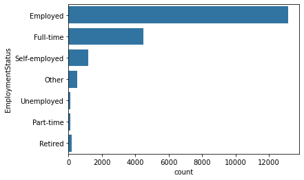

```python
#Another catagorical variable plotted('EmploymentStatus')
base_color = sb.color_palette()[0]
sb.countplot(data= df_clean, y ='EmploymentStatus', color=base_color)
```

The highest number of borrowers are employed, which can either mean full time, part time or self employed. The second highest are borrowers who recorded the condition of their employment(Full-time). With the above plot, it shows that most of the borrowers have jobs with a very few who are unemployed while the others are retired.

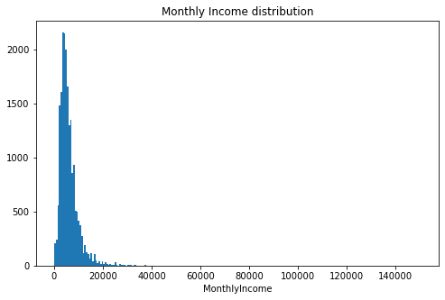

```python
#The quantitative variables are plotted on a standard scaled plot to get a view of the data
binsize = 650
bins = np.arange(0, df_clean['MonthlyIncome'].max()+binsize, binsize)

plt.figure(figsize=[8,5])
plt.hist(data=df_clean, x='MonthlyIncome', bins=bins)
plt.xlabel('MonthlyIncome')
plt.title('Monthly Income distribution')
plt.show()
```

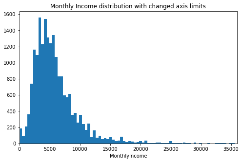

```python
#Plot the above similar lot but with changed axis limits to bound the area in focus
binsize = 450
bins = np.arange(0, df_clean['MonthlyIncome'].max()+binsize, binsize)

plt.figure(figsize=[8,5])
plt.xlim(0,36000)
plt.hist(data=df_clean, x='MonthlyIncome', bins=bins)
plt.xlabel('MonthlyIncome')
plt.title('Monthly Income distribution with changed axis limits')
plt.show()
```

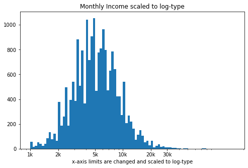

```python
#Scaling the x-axis to log-type
log_binsize = 0.025
bins = 10 ** np.arange(3, np.log10(df_clean['MonthlyIncome'].max())+log_binsize, log_binsize)

plt.figure(figsize=[8,5])
plt.hist(data=df_clean, x= 'MonthlyIncome', bins=bins);
plt.xscale('log')
plt.xticks([1e3, 2e3, 5e3, 1e4, 2e4, 3e4], ['1k', '2k', '5k', '10k', '20k', '30k'])
plt.title('Monthly Income scaled to log-type')
plt.xlabel('x-axis limits are changed and scaled to log-type');
```

The histogram plot for MonthlyIncome is highly skewed to the right. I have plotted a second histogram with changed axis limits in order to focus on a certain area. The second plot is a bit clearer and it shows that most of the borrowers have a monthly income of 1000 - 8000. The third MonthlyIncome plot is scaled to log-type and shows a better view of the Monthly Income distribution for the borrowers. There are a few borrowers with an income of around 1000-2000 but a high percentage of the borrowers earn from about 3000-10000.

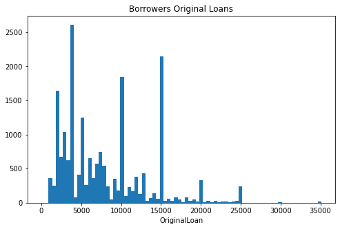

```python
binsize = 450
bins = np.arange(0, df_clean['OriginalLoan'].max()+binsize, binsize)

plt.figure(figsize=[8,5])
plt.hist(data=df_clean, x='OriginalLoan', bins=bins)
plt.xlabel('OriginalLoan')
plt.title('Borrowers Original Loans')
plt.show()
```

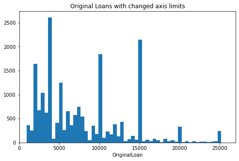

```python
binsize = 450
bins = np.arange(0, df_clean['OriginalLoan'].max()+binsize, binsize)

plt.figure(figsize=[8,5])
plt.xlim(0,27000)
plt.hist(data=df_clean, x='OriginalLoan', bins=bins)
plt.xlabel('OriginalLoan')
plt.title('Original Loans with changed axis limits')

plt.show()
```

The OriginlLoan plot is supposed to show the initial amount borrowers got for their loans. There's no specific pattern in the plots other than most borrowers got 4000-4500 amount in approved loans while the second largest group got 15000 amount in approved loans. From the plots, one guess is that the higher the Original Loan amount a borrowers gets, the higher their monthly income and vice versa.

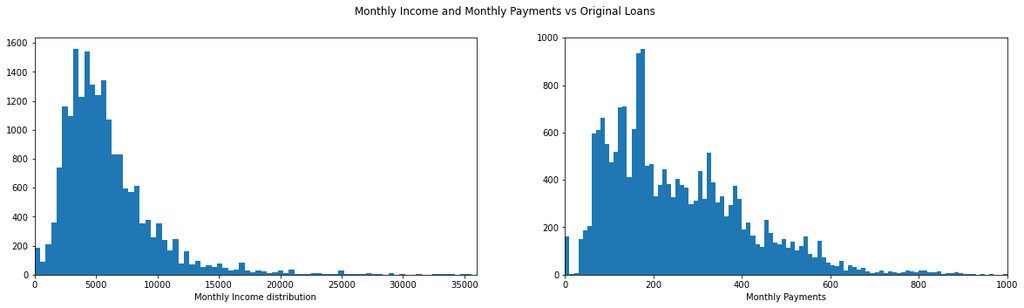

```python
#Plotting MonthlyPayments and MonthlyIncome side by side in subplots
plt.figure(figsize=[20,5])

plt.subplot(1,2,1)
bins = np.arange(0, df_clean['MonthlyIncome'].max()+450, 450)
plt.xlim(0, 36000)
plt.xlabel('Monthly Income distribution')
plt.hist(data=df_clean, x= 'MonthlyIncome', bins=bins);

plt.subplot(1,2,2)
bins = np.arange(0, df_clean['MonthlyPayment'].max()+10, 10)
plt.xlim(0, 1000)
plt.xlabel('Monthly Payments')
plt.hist(data=df_clean, x='MonthlyPayment', bins=bins);

plt.suptitle('Monthly Income and Monthly Payments vs Original Loans')
```